# Mapping the occurence of Cape Fur Seal carcasses

Muhammad Uzair Davids

2025-02-27

## **Load in the packages**

```r
library(rinat)             # iNaturalist data
library(sf)                # Spatial data handling
```

```r
library(ggplot2)           # Static maps
library(ggspatial)         # Static maps
library(leaflet)           # Interactive maps
library(leaflet.extras)    # Allows more interactive features
library(rnaturalearth)     # Base map data
library(rnaturalearthdata) # Additional features
library(tidyverse)         # Data cleaning
library(dplyr)             # Data wrangling
library(readr)             # Reading/writing .csv files
library(stringr)           # Advanced string filtering
library(lubridate)         # For date filtering
```

## **Getting our data from iNat**

Before we can get started, we first need to get our data. We will be using data from iNaturalist. So to ensure quality data we need to specify that it the data must be *research grade* and we also only want data from South Africa. As for how many results we need to draw from, if you look up [Cape Fur Seal](https://www.inaturalist.org/observations?taxon_id=346947) on iNat, 4,434 observations show up, so we’ll just set `maxresults =` to 4000 to make sure we draw from as many of those observations as possible (and just hope my laptop will survive).

```r
# Query iNaturalist for Cape Fur Seal (Arctocephalus pusillus) sightings
data_seal <- get_inat_obs(
  taxon_name = "Arctocephalus pusillus",
  quality = "research", # Only research-grade sightings
  geo = TRUE,           # Must have geolocation
  place_id = 113055,    # Place ID for South Africa in iNaturalist
  maxresults = 4000     # Adjust as needed
)
```

## **Filter observations**

The data currently contained in `data_seal` consists of all research grade observations of Cape Fur Seals in South Africa, dead or alive, but, we specifically want observations of *dead* seals. It’s time to *“cull”*.

The first step is to define the keywords that indicate death in seals. These keywords will help us to filter out observations of dead seals. However, these keywords may also bring back results which retrieve observations of skeletal remains, which is not what we want, since the presence of skeletal remains may mean that the animal died long before the earliest identified case of rabies outbreaks, which according to a government report is 5 August 2022 (Maja, 2024). For this reason we will also be filtering out observations before this date.

```r
# Define keywords indicating death in the seals
death_keywords <- c("dead",
                    "died",
                    "carcass",
                    "deceased",
                    "stranded",
                    "washed up",
                    "lifeless",
                    "corpse")

# Define exclusion keywords for skeletal remains
exclude_keywords <- c("skeleton",
                      "skeletal",
                      "bones",
                      "skull")
```

Now that we’ve set the keywords, we should check the column names to know which columns to filter for the keywords.

```r
# Check available column names to know which columns to check for
colnames(data_seal)
```

```
##  [1] "scientific_name"                  "datetime"
##  [3] "description"                      "place_guess"
##  [5] "latitude"                         "longitude"
##  [7] "tag_list"                         "common_name"
##  [9] "url"                              "image_url"
## [11] "user_login"                       "id"
## [13] "species_guess"                    "iconic_taxon_name"
## [15] "taxon_id"                         "num_identification_agreements"
## [17] "num_identification_disagreements" "observed_on_string"
## [19] "observed_on"                      "time_observed_at"
## [21] "time_zone"                        "positional_accuracy"
## [23] "public_positional_accuracy"       "geoprivacy"
## [25] "taxon_geoprivacy"                 "coordinates_obscured"
## [27] "positioning_method"               "positioning_device"
## [29] "user_id"                          "user_name"
## [31] "created_at"                       "updated_at"
## [33] "quality_grade"                    "license"
## [35] "sound_url"                        "oauth_application_id"
## [37] "captive_cultivated"
```

So, the main columns we would want to check are the `tag_list` and `description` columns, since these contain any additional information regarding the observation. So let’s filter these.

```r
# Convert tags and description to lowercase to avoid case sensitivity when filtering
seal_dead <- data_seal %>%
  filter(
    str_detect(tolower(tag_list),
               paste(death_keywords, collapse = "|")) |  # Check tags
    str_detect(tolower(description),
               paste(death_keywords, collapse = "|"))    # Check description
  ) %>%
  filter(
    # Must NOT contain skeletal-related words
    !str_detect(tolower(tag_list), paste(exclude_keywords, collapse = "|")) &
    !str_detect(tolower(description), paste(exclude_keywords, collapse = "|"))
  ) %>%
  filter(
    # Ensures observations are no earlier than 5 August 2022
    observed_on >= as.Date("2022-08-05")
  )

# Check the first few rows to make sure the data is correct
head(seal_dead)
```

```
##                   scientific_name                  datetime
## 1 Arctocephalus pusillus pusillus 2025-01-29 12:48:31 +0200
## 2          Arctocephalus pusillus 2025-01-10 19:02:55 +0200
## 3 Arctocephalus pusillus pusillus 2024-12-22 12:48:39 +0200
## 4 Arctocephalus pusillus pusillus 2024-12-19 20:14:18 +0200
## 5 Arctocephalus pusillus pusillus 2024-12-15 19:01:04 +0200
## 6 Arctocephalus pusillus pusillus 2024-12-15 19:00:57 +0200
##                                                                             description
## 1                                                                                  Dead
## 2 Seen in the marina floating with flipper out of the water a few hours before it died.
## 3                       Juvenile, washed up on Hout Bay beach, east of Disa River mouth
## 4                                              Dead, juvenile blood coming from mouth.
## 5           Smallish, dead, washed up after full moon high tide. Lots of kelp present.
## 6           Smallish, dead, washed up after full moon high tide. Lots of kelp present.
##                                               place_guess  latitude longitude
```

[output cut: 69 more lines]

# **Loading the colony and rabies outbreak datasets**

So, we’ve retrieved all the data of seal carcasses observed since 5 August 2022. Now we need data of the seal colonies and rabies outbreaks. Unfortunately, there are no openly available datasets which contain this information, so we’ll be using data I compiled based on a paper by Kirkman *et al.* (2012) and a government report by Maja (2024).

**NB:** The location of *all* colonies in South Africa are likely not well represented by the data I compiled from the paper and report, especially since the Kirkman *et al.* (2012) paper only contains the location data of breeding colonies and the government report only contains the colonies or locations where rabies outbreaks were reported. It should also be noted that colony data from Maja (2024) was only taken from areas strictly labelled with “colony”. The Kirkman *et al.* (2012) data may also be slightly off, since the original coordinates were in *degrees and decimal minutes* format rather than *decimal degrees* format, which is the coordinate format we want. I had tried to correct some of these when I compiled the `.csv`, but some locations were difficult to pinpoint by name, so view the colony locations with a grain of salt. I also added some colonies later based on areas I found searching for the correct location of the other colonies on Google Earth.

Anyhoo, let’s start by loading the colony data which I compiled into a .`csv` using information from both Kirkman *et al* (2012) and Maja (2024).

```r
# Read in the .csv
data_colony <- read.csv("data/data_colony.csv")

# Get a glimpse at our data
head(data_colony)
```

```
##      Colony.Name  Latitude Longitude
## 1        Robberg -34.10034  23.38547
## 2 Seal Island MB -34.15090  22.11980
## 3     Quoin Rock -34.78686  19.66670
## 4    Geyser Rock -34.68867  19.41250
## 5 Seal Island FB -34.13741  18.58272
## 6  Duiker Island -34.05855  18.32672
```

Now for the rabies data. Note that for the rabies, it is not the exact location the outbreak occurred, but an approximate guess - since the government report has made my life very difficult by providing a very broad indicator of the location of the outbreaks, e.g. “Cape Town”. Also note that I don’t separate the outbreak locations by the date the samples were taken (which they mention in the government report) since I’m more interested in where the outbreak occurred in relation to the location of the colonies and where carcasses are washing up.

```r
# Read in the .csv
data_rabies <- read.csv("data/data_rabies.csv")

# Take a look at the data
head(data_rabies)
```

```
##              Name  Latitude Longitude
## 1       Kommetjie -34.13700  18.32846
## 2       Noordhoek -34.09765  18.35387
## 3        Kalk Bay -34.12782  18.44864
## 4   Melkbosstrand -33.72435  18.44215
## 5       Fish Hoek -34.13769  18.43373
## 6 Plettenberg Bay -34.07852  23.37160
```

## **Convert the data to a spatial object (sf)**

Now that we’ve got the data, we can save the observations as a spatial object that can be plotted. As for the projection of the data, we will set it to WGS84 since the end goal is to map the map interactive, and the `leaflet` package requires data to be projected at global projection.

```r
# Convert the dead seal data to sf object (WGS84 - EPSG:4326)
seal_dead_sf <- st_as_sf(seal_dead,
                         coords = c("longitude", "latitude"),
                         crs = 4326)

# Convert the colony data to sf object (WGS84 - EPSG:4326)
colony_sf <- st_as_sf(data_colony,
                         coords = c("Longitude", "Latitude"),
                         crs = 4326)

# Convert the rabies data to sf object (WGS84 - EPSG:4326)
rabies_sf <- st_as_sf(data_rabies,
                         coords = c("Longitude", "Latitude"),
                         crs = 4326)
```

## **Getting the base map and plotting our points**

So, we have our point data, but we don’t have a base map to plot the data on. Let’s download a base map of South Africa from the `rnaturalearth` package.

```r
# Get world map data
world <- ne_countries(scale = "medium", returnclass = "sf")

# Filter for South Africa
south_africa <- world[world$name == "South Africa", ]
```

Now that we have the base map saved, we can plot our points.

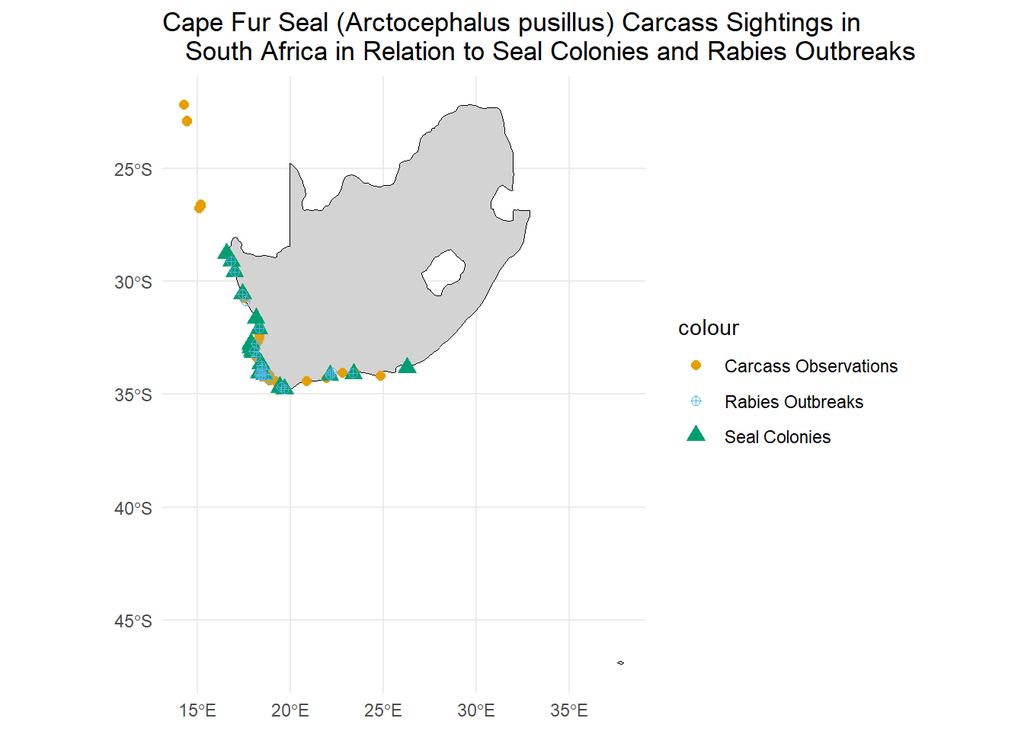

```r
# Plot base map with
ggplot() +

  # Add the South African boundary
  geom_sf(data = south_africa, fill = "lightgray", color = "black") +

  # Add the seal carcass observations
  geom_sf(data = seal_dead_sf, aes(color = "Carcass Observations"),
          size = 2) +

  # Add the seal colony data
  geom_sf(data = colony_sf, aes(color = "Seal Colonies"), shape = 17,
          size = 3) +

  # Add the rabies outbreak data
  geom_sf(data = rabies_sf, aes(color = "Rabies Outbreaks"), shape = 10,
          size = 2) +

  # Colour blind friendly colour palette
  scale_color_manual(values = c("#E69F00", "#56B4E9", "#009E73")) +

  labs(title =
  "Cape Fur Seal (Arctocephalus pusillus) Carcass Sightings in
   South Africa in Relation to Seal Colonies and Rabies Outbreaks") +

  theme_minimal()
```

## **Some extra data wrangling**

You’ll notice that even though we set `place_id` to only pull iNat data from South Africa, some of the points are way outside the South African boundary, and extend into Namibia, so we’ll need to get rid of those. To do this, we can create a spatial filter.

```r
filter_south_africa_sf <- function(seal_dead_sf) {
  # Ensure the input is an sf object
  if (!inherits(seal_dead_sf, "sf")) {
    stop("Error: seal_dead_sf must be an sf object with point geometries.")
  }

  # Filter points that fall inside South Africa
  filtered_sf <- st_intersection(seal_dead_sf, south_africa)

  return(filtered_sf)  # Return filtered dataset as an sf object
}

# Apply function to filter seal_dead_sf
seal_dead_sa <- filter_south_africa_sf(seal_dead_sf)
# Preview filtered data
print(seal_dead_sa)
```

```
## Simple feature collection with 153 features and 203 fields
## Geometry type: POINT
## Dimension:     XY
## Bounding box:  xmin: 17.51498 ymin: -34.67704 xmax: 23.43381 ymax: -30.72441
## Geodetic CRS:  WGS 84
## First 10 features:
##                    scientific_name                  datetime
## 1  Arctocephalus pusillus pusillus 2025-01-29 12:48:31 +0200
## 3  Arctocephalus pusillus pusillus 2024-12-22 12:48:39 +0200
## 4  Arctocephalus pusillus pusillus 2024-12-19 20:14:18 +0200
## 5  Arctocephalus pusillus pusillus 2024-12-15 19:01:04 +0200
## 6  Arctocephalus pusillus pusillus 2024-12-15 19:00:57 +0200
## 7  Arctocephalus pusillus pusillus 2024-12-15 19:00:50 +0200
## 8  Arctocephalus pusillus pusillus 2024-12-15 19:00:09 +0200
## 9  Arctocephalus pusillus pusillus 2024-12-15 18:57:52 +0200
```

[output cut: 431 more lines]

Now that we’ve set the filter, let’s try plotting the points on the map again.

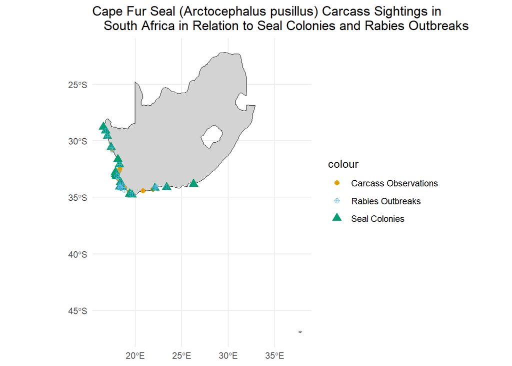

```r
# Plot base map with
ggplot() +

  # Add the South African boundary
  geom_sf(data = south_africa, fill = "lightgray", color = "black") +

  # Add the updated seal carcass observations
  geom_sf(data = seal_dead_sa, aes(color = "Carcass Observations"),
          size = 2) +

  # Add the seal colony data
  geom_sf(data = colony_sf, aes(color = "Seal Colonies"), shape = 17,
          size = 3) +

  # Add the rabies outbreak data
  geom_sf(data = rabies_sf, aes(color = "Rabies Outbreaks"), shape = 10,
          size = 2) +

  # Colour blind friendly colour palette
  scale_color_manual(values = c("#E69F00", "#56B4E9", "#009E73")) +

  labs(title =
  "Cape Fur Seal (Arctocephalus pusillus) Carcass Sightings in
   South Africa in Relation to Seal Colonies and Rabies Outbreaks") +

  theme_minimal()
```

It worked! Now onto the interactive map!

Okay, cool, now that that’s sorted, we can also save the data as `.csv` or `.geojson` if we wanted - I’ll do it so that other’s can view the metadata.

```r
# Save as .csv in the data file so we have a file with the necessary metadata
# available for anyone interested
write_csv(seal_dead_sa, "data/seal_dead.csv")

# Save as GeoJSON for GIS applications for anyone who would like to download
# the file for themselves
st_write(seal_dead_sa, "data/seal_dead.geojson", delete_dsn = TRUE)
```

```
## Deleting source `data/seal_dead.geojson' using driver `GeoJSON'
## Writing layer `seal_dead' to data source
##   `data/seal_dead.geojson' using driver `GeoJSON'
## Writing 153 features with 203 fields and geometry type Point.
```

```r
st_write(colony_sf, "data/seal_colony.geojson", delete_dsn = TRUE)
```

```
## Deleting source `data/seal_colony.geojson' using driver `GeoJSON'
## Writing layer `seal_colony' to data source
##   `data/seal_colony.geojson' using driver `GeoJSON'
## Writing 20 features with 1 fields and geometry type Point.
```

```r
st_write(rabies_sf, "data/seal_rabies.geojson", delete_dsn = TRUE)
```

```
## Deleting source `data/seal_rabies.geojson' using driver `GeoJSON'
## Writing layer `seal_rabies' to data source
##   `data/seal_rabies.geojson' using driver `GeoJSON'
## Writing 25 features with 1 fields and geometry type Point.
```

## **Making the map interactive**

To make our map interactive we’ll use `leaflet`, this will allow people to zoom in and out of the map and zoom in on the individual points on the map, which are currently cluttered. We’ll also create pop-ups that allow the viewer to see the images attached to each observation, when the observation was made, who it was made by, and an interactive link to the original observation.

```r
# Create leaflet map
leaflet() %>%
  addProviderTiles("Esri.WorldImagery") %>%  # High-detail satellite imagery

  # Add Seal Carcass Observations with detailed popups
  addCircleMarkers(data = seal_dead_sa,
                   color = "#E69F00",
                   radius = 3,
                   popup = ~paste(
                     "<b>Recorded by:</b>", user_login, "<br>",
                     "<b>Location:</b>", place_guess, "<br>",
                     "<b>Date:</b>", observed_on, "<br>",
                     "<b>Description:</b>", description, "<br>",
                     "<b>Tags:</b>", tag_list, "<br>",
                     "<a href='", url,
                     "' target='_blank'>View on iNaturalist</a>",
                     "<img src='", image_url, "' width='200px' height='150px'>"
                   )) %>%

  # Add Seal Colonies with coordinate popups
  addCircleMarkers(data = colony_sf,
                   color = "#56B4E9",
                   radius = 4,
                   popup = ~paste(
                     "<b>Colony:</b>", Colony.Name, "<br>"
                   )) %>%

  # Add Seal Rabies Outbreaks with coordinate popups
  addCircleMarkers(data = rabies_sf,
                   color = "#009E73",
                   radius = 4,
                   popup = ~paste(
                     "<b>Location of Outbreak:</b>", Name, "<br>"
                   )) %>%

  # Add Legend
  addLegend(position = "bottomright",
            colors = c("#E69F00", "#56B4E9", "#009E73"),
            labels = c("Carcass observations", "Seal breeding colonies",
                       "Location of rabies outbreaks")) %>%

  # Add Scale Bar and MiniMap
  addScaleBar(position = "bottomleft") %>%
  addMiniMap(toggleDisplay = TRUE)
```

[interactive chart not shown]

And there you have it folks! A pretty picture and the end of this assignment.

## **References**

Kirkman, S.P., Yemane, D., Oosthuizen, W.H., Meÿer, M.A., Kotze, P.G.H., Skrypzeck, H., Vaz Velho, F. and Underhill, L.G. (2012). Spatio-temporal shifts of the dynamic Cape fur seal population in southern Africa, based on aerial censuses (1972-2009). Marine Mammal Science, 29(3), pp.497–524. doi:https://doi.org/10.1111/j.1748-7692.2012.00584.x.

Maja, M. (2024). Rabies in Cape fur seals: outbreak update report. Department of Agriculture, Land Reform and Rural Development. Available at: https://www.dalrrd.gov.za/images/outbreaks/Rabies/2024/rabies-in-seals_dalrrd-report_oct2024_final.pdf.